# Stock Prices Forecasting

# Packages

Load the packages.

```r
library(forecast)
```

```r
library(ggplot2)
library(readr)
```

# Viewing and Decomposing the Data

This commant will let us view the plot of the PSEI time series

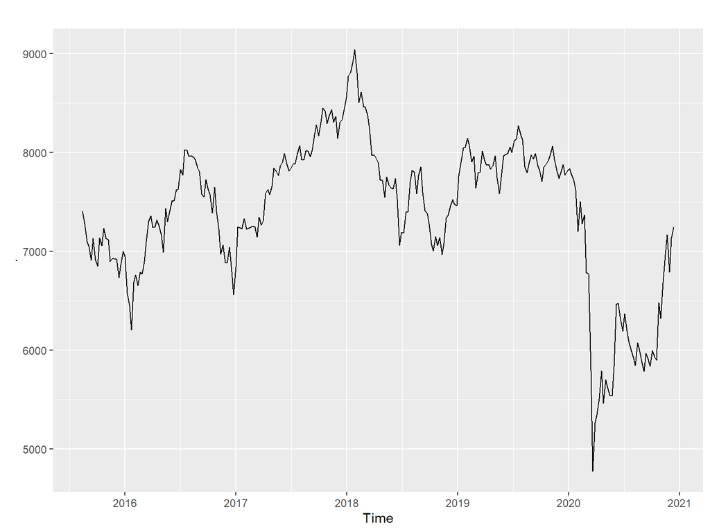

```r
PSEI <- read_csv("~/R/SPP/CSV/PSEI.csv", col_types = cols(Week = col_date(format = "%Y-%m-%d")))
psei <- ts(PSEI[,2], freq=365.25/7, start=2015+226/365.25)
psei %>%
  autoplot()
```

This will show the trend, seasonal, and random component of the time series.

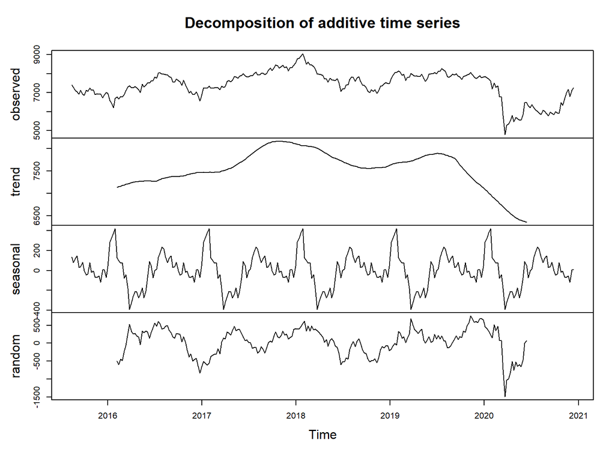

```r
plot(decompose(psei))
```

# Forecasting

This is a validation of last week’s forecast.

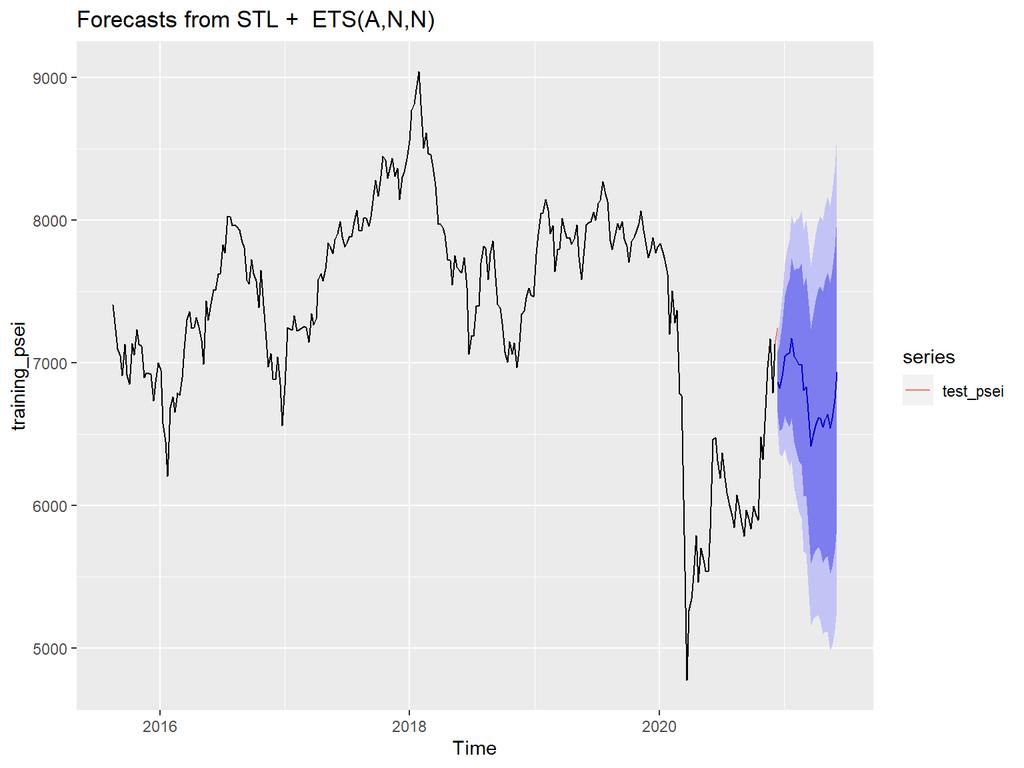

```r
training_psei <- subset(psei, end=length(psei)-1)
test_psei <- subset(psei, start=length(psei)-1)
fc_training_psei<-forecast(training_psei)
fc_training_psei %>%
  forecast(h=26) %>%
  autoplot() +autolayer(test_psei)
```

These are the point forecast, the 80% and the 95% confidence interval.

```r
fc_training_psei
```

```
##          Point Forecast    Lo 80    Hi 80    Lo 95     Hi 95
## 2020.947       6867.335 6654.971 7079.698 6542.553  7192.117
## 2020.966       6824.983 6524.696 7125.270 6365.733  7284.232
## 2020.985       6908.385 6540.627 7276.144 6345.947  7470.823
## 2021.004       7050.295 6625.654 7474.937 6400.863  7699.728
## 2021.023       7061.336 6586.579 7536.093 6335.258  7787.415
## 2021.042       7071.576 6551.510 7591.642 6276.204  7866.948
## 2021.062       7174.837 6613.105 7736.568 6315.742  8033.931
## 2021.081       7048.126 6447.613 7648.640 6129.720  7966.532
## 2021.100       7025.440 6388.502 7662.378 6051.327  7999.553
## 2021.119       6988.068 6316.678 7659.457 5961.266  8014.870
## 2021.138       6991.846 6287.688 7696.004 5914.929  8068.762
## 2021.157       6808.915 6073.448 7544.383 5684.115  7933.716
## 2021.177       6834.216 6068.719 7599.714 5663.489  8004.944
## 2021.196       6658.535 5864.142 7452.928 5443.616  7873.454
## 2021.215       6419.318 5597.044 7241.591 5161.758  7676.877
## 2021.234       6504.192 5654.952 7353.432 5205.392  7802.992
## 2021.253       6560.427 5685.051 7435.802 5221.655  7899.198
## 2021.272       6612.998 5712.245 7513.752 5235.415  7990.581
## 2021.292       6612.408 5686.972 7537.843 5197.077  8027.739
## 2021.311       6550.949 5601.473 7500.424 5098.851  8003.047
## 2021.330       6601.669 5628.746 7574.591 5113.712  8089.625
## 2021.349       6641.680 5645.862 7637.497 5118.708  8164.651
## 2021.368       6543.962 5525.765 7562.160 4986.763  8101.161
## 2021.387       6612.562 5572.466 7652.658 5021.872  8203.252
## 2021.407       6750.853 5689.310 7812.396 5127.363  8374.343
## 2021.426       6937.724 5855.158 8020.289 5282.082  8593.365
## 2021.445       6897.703 5794.515 8000.890 5210.523  8584.882
## 2021.464       6769.564 5646.133 7892.994 5051.425  8487.703
## 2021.483       6798.292 5654.976 7941.607 5049.741  8546.842
## 2021.502       6868.806 5705.946 8031.667 5090.365  8647.248
## 2021.522       6923.826 5741.743 8105.908 5115.987  8731.664
## 2021.541       6952.651 5751.655 8153.647 5115.885  8789.416
## 2021.560       6988.969 5769.352 8208.587 5123.726  8854.213
## 2021.579       6964.062 5726.104 8202.020 5070.768  8857.355
## 2021.598       6932.910 5676.879 8188.941 5011.976  8853.844
## 2021.617       6932.139 5658.291 8205.987 4983.957  8880.321
## 2021.637       6950.504 5659.085 8241.923 4975.449  8925.558
## 2021.656       6948.396 5639.642 8257.150 4946.830  8949.962
## 2021.675       6842.778 5516.916 8168.640 4815.047  8870.509
```

[output cut: 50 more lines]

```
## 2022.652       6948.396 4934.275 8962.517 3868.063 10028.729
## 2022.671       6842.778 4817.498 8868.058 3745.380  9940.176
## 2022.691       6907.148 4870.771 8943.526 3792.778 10021.519
## 2022.710       6894.568 4847.154 8941.983 3763.318 10025.819
## 2022.729       6817.533 4759.140 8875.926 3669.493  9965.573
## 2022.748       6837.272 4767.959 8906.584 3672.531 10002.012
## 2022.767       6837.927 4757.752 8918.102 3656.574 10019.280
## 2022.786       6922.484 4831.503 9013.466 3724.605 10120.364
## 2022.806       6976.489 4874.758 9078.221 3762.168 10190.811
## 2022.825       6966.282 4853.854 9078.710 3735.603 10196.961
## 2022.844       6989.087 4866.018 9112.157 3742.133 10236.042
## 2022.863       7047.440 4913.781 9181.098 3784.291 10310.589
## 2022.882       7111.270 4967.075 9255.465 3832.006 10390.533
## 2022.901       6991.831 4837.151 9146.511 3696.532 10287.130
## 2022.921       7134.506 4969.392 9299.620 3823.249 10445.763
```

This is next week’s forecast.

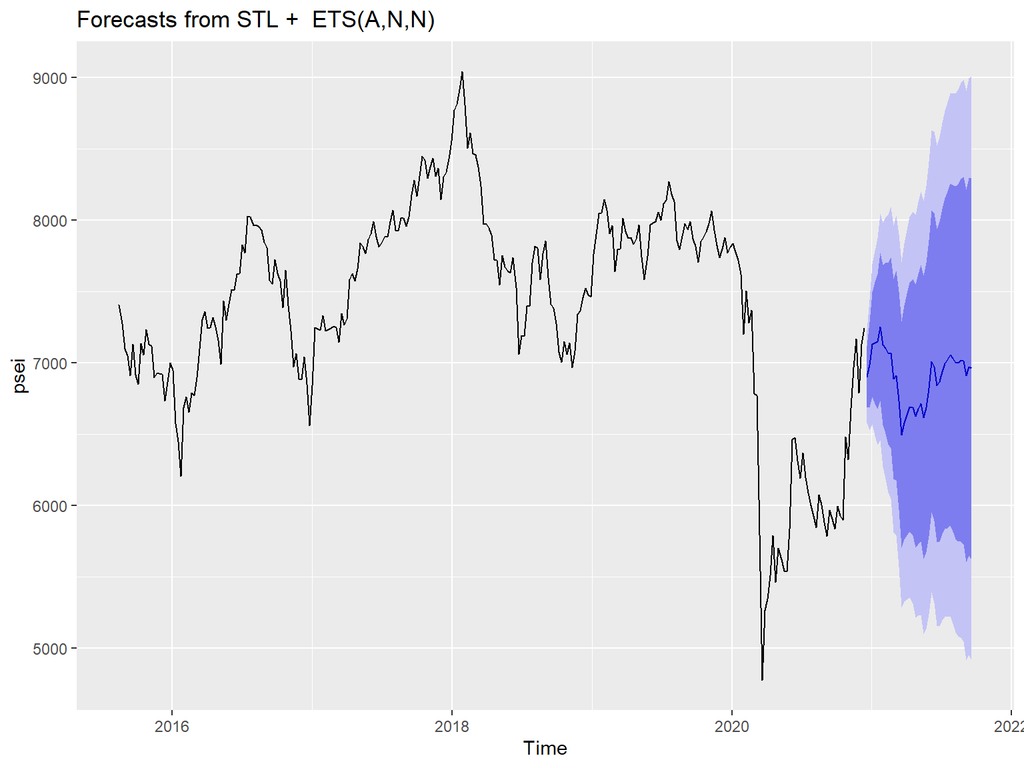

```r
fc_psei<-forecast(psei)
fc_psei %>%
  forecast(h=40) %>%
  autoplot()
```

These are the point forecast, the 80% and the 95% confidence interval.

```r
fc_psei
```

```
##          Point Forecast    Lo 80    Hi 80    Lo 95     Hi 95
## 2020.966       6904.550 6692.890 7116.210 6580.843  7228.256
## 2020.985       6988.009 6688.692 7287.327 6530.243  7445.776
## 2021.004       7129.978 6763.397 7496.559 6569.340  7690.615
## 2021.023       7141.077 6717.789 7564.365 6493.714  7788.440
## 2021.042       7151.376 6678.128 7624.624 6427.606  7875.146
## 2021.062       7254.695 6736.280 7773.111 6461.848  8047.543
## 2021.081       7128.045 6568.093 7687.996 6271.673  7984.416
## 2021.100       7105.418 6506.806 7704.030 6189.920  8020.916
## 2021.119       7067.822 6432.899 7702.745 6096.791  8038.853
## 2021.138       7071.376 6402.109 7740.643 6047.821  8094.931
## 2021.157       6888.222 6186.289 7590.154 5814.709  7961.734
## 2021.177       6913.297 6180.154 7646.441 5792.051  8034.544
## 2021.196       6737.391 5974.311 7500.471 5570.361  7904.421
## 2021.215       6497.947 5706.062 7289.832 5286.864  7709.030
## 2021.234       6582.596 5762.917 7402.274 5329.006  7836.185
## 2021.253       6638.603 5792.043 7485.163 5343.902  7933.304
## 2021.272       6690.947 5818.334 7563.561 5356.400  8025.494
## 2021.292       6689.860 5791.949 7587.772 5316.623  8063.097
## 2021.311       6627.905 5705.389 7550.421 5217.039  8038.772
## 2021.330       6678.129 5731.648 7624.610 5230.611  8125.647
## 2021.349       6717.645 5747.790 7687.499 5234.380  8200.909
## 2021.368       6619.432 5626.754 7612.109 5101.263  8137.601
## 2021.387       6687.536 5672.549 7702.524 5135.247  8239.826
## 2021.407       6825.333 5788.515 7862.150 5239.657  8411.008
## 2021.426       7011.709 5953.512 8069.906 5393.336  8630.082
## 2021.445       6971.194 5892.041 8050.348 5320.772  8621.617
## 2021.464       6842.531 5742.821 7942.242 5160.669  8524.393
## 2021.483       6870.734 5750.844 7990.624 5158.010  8583.458
## 2021.502       6940.724 5801.011 8080.436 5197.684  8683.764
## 2021.522       6995.219 5836.023 8154.415 5222.381  8768.056
## 2021.541       7023.520 5845.163 8201.878 5221.378  8825.663
## 2021.560       7059.315 5862.103 8256.527 5228.337  8890.293
## 2021.579       7033.883 5818.109 8249.658 5174.516  8893.251
## 2021.598       7003.093 5769.035 8237.151 5115.764  8890.422
## 2021.617       7001.845 5749.771 8253.919 5086.963  8916.727
## 2021.637       7019.711 5749.876 8289.546 5077.665  8961.756
## 2021.656       7017.103 5729.753 8304.454 5048.270  8985.936
## 2021.675       6910.986 5606.355 8215.617 4915.725  8906.247
## 2021.694       6974.857 5653.171 8296.543 4953.513  8996.201
```

[output cut: 50 more lines]

```
## 2022.671       6910.986 4903.204 8918.768 3840.348  9981.624
## 2022.691       6974.857 4955.952 8993.763 3887.208 10062.507
## 2022.710       6961.778 4931.810 8991.746 3857.209 10066.346
## 2022.729       6884.242 4843.271 8925.213 3762.847 10005.637
## 2022.748       6903.480 4851.566 8955.395 3765.348 10041.612
## 2022.767       6903.635 4840.835 8966.435 3748.855 10058.415
## 2022.786       6987.692 4914.064 9061.320 3816.351 10159.032
## 2022.806       7041.127 4956.726 9125.527 3853.312 10228.942
## 2022.825       7030.350 4935.233 9125.467 3826.145 10234.555
## 2022.844       7052.586 4946.806 9158.365 3832.074 10273.097
## 2022.863       7110.369 4993.981 9226.757 3873.633 10347.105
## 2022.882       7173.630 5046.687 9300.573 3920.751 10426.509
## 2022.901       7053.623 4916.176 9191.070 3784.680 10322.566
## 2022.921       7195.730 5047.831 9343.629 3910.802 10480.658
## 2022.940       7246.154 5087.853 9404.454 3945.318 10546.990
```

```r
tail(psei)
```

```
## Time Series:
## Start = 2020.8507871321
## End = 2020.94661190965
## Frequency = 52.1785714285714
##        Price
## [1,] 6685.69
## [2,] 6969.88
## [3,] 7169.79
## [4,] 6791.46
## [5,] 7134.56
## [6,] 7246.16
```

```r
min(psei)
```

```
## [1] 4778.76
```

```r
max(psei)
```

```
## [1] 9041.2
```

```r
which.min(psei)
```

```
## [1] 241
```

# ARIMA

This is a command for auto arima.

```r
bestfit_psei <- list(aicc=Inf)
for(i in 1:25)
{
  fit_psei <- auto.arima(psei, xreg=fourier(psei, K=i), seasonal=FALSE)
  if(fit_psei$aicc < bestfit_psei$aicc)
    bestfit_psei <- fit_psei
  else break;
}
```

The summary of the ARIMA model.

```r
summary(bestfit_psei)
```

```
## Series: psei
## Regression with ARIMA(0,1,0) errors
##
## Coefficients:
##          S1-52     C1-52     S2-52     C2-52
##        76.1585   -6.1622  -97.6236  123.4915
## s.e.  131.7154  129.4198   65.3417   65.4326
##
## sigma^2 estimated as 34707:  log likelihood=-1845.65
## AIC=3701.31   AICc=3701.53   BIC=3719.45
##
## Training set error measures:
##                     ME     RMSE      MAE         MPE     MAPE      MASE
## Training set -0.610717 184.6221 131.8597 -0.04753934 1.877225 0.1616295
##                     ACF1
## Training set -0.01308952
```

The plot of the ARIMA model.

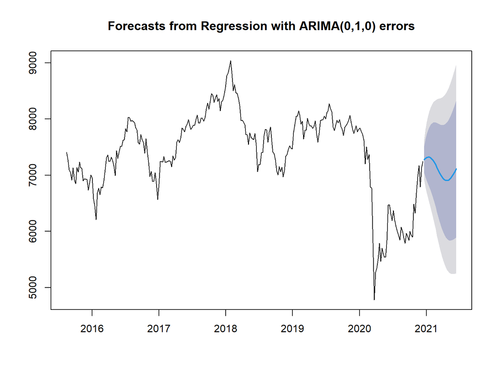

```r
fc_arima_psei <- forecast(bestfit_psei, xreg=fourier(psei, K=2, h=26))
plot(fc_arima_psei)
```

These are the point forecast, the 80% and the 95% confidence interval.

```r
fc_arima_psei
```

```
##          Point Forecast    Lo 80    Hi 80    Lo 95    Hi 95
## 2020.966       7275.305 7036.553 7514.056 6910.165 7640.444
## 2020.985       7298.755 6961.109 7636.401 6782.370 7815.140
## 2021.004       7314.899 6901.369 7728.429 6682.459 7947.339
## 2021.023       7322.511 6845.008 7800.014 6592.232 8052.790
## 2021.042       7320.828 6786.963 7854.693 6504.352 8137.304
## 2021.062       7309.599 6724.779 7894.419 6415.194 8204.004
## 2021.081       7289.102 6657.424 7920.780 6323.034 8255.170
## 2021.100       7260.136 6584.844 7935.428 6227.366 8292.906
## 2021.119       7223.980 6507.724 7940.235 6128.562 8319.398
## 2021.138       7182.322 6427.323 7937.321 6027.650 8336.994
## 2021.157       7137.172 6345.322 7929.022 5926.142 8348.202
## 2021.177       7090.749 6263.688 7917.809 5825.869 8355.628
## 2021.196       7045.356 6184.525 7906.188 5728.828 8361.885
## 2021.215       7003.260 6109.933 7896.587 5637.034 8369.486
## 2021.234       6966.557 6041.876 7891.239 5552.379 8380.735
## 2021.253       6937.064 5982.057 7892.071 5476.507 8397.621
## 2021.272       6916.212 5931.813 7900.611 5410.704 8421.720
## 2021.292       6904.973 5892.035 7917.911 5355.818 8454.128
## 2021.311       6903.803 5863.108 7944.497 5312.198 8495.408
## 2021.330       6912.619 5844.889 7980.350 5279.667 8545.572
## 2021.349       6930.810 5836.712 8024.908 5257.532 8604.089
## 2021.368       6957.268 5837.423 8077.113 5244.613 8669.923
## 2021.387       6990.456 5845.443 8135.469 5239.310 8741.602
## 2021.407       7028.497 5858.857 8198.137 5239.687 8817.307
## 2021.426       7069.281 5875.522 8263.040 5243.585 8894.978
## 2021.445       7110.586 5893.186 8327.985 5248.733 8972.438
```

# Manual ARIMA

This will generate 12 arima models.

```r
fit_psei1 <- auto.arima(psei, xreg=fourier(psei, K=1), seasonal=FALSE)
fit_psei2 <- auto.arima(psei, xreg=fourier(psei, K=2), seasonal=FALSE)
fit_psei3 <- auto.arima(psei, xreg=fourier(psei, K=3), seasonal=FALSE)
fit_psei4 <- auto.arima(psei, xreg=fourier(psei, K=4), seasonal=FALSE)
fit_psei5 <- auto.arima(psei, xreg=fourier(psei, K=5), seasonal=FALSE)
fit_psei6 <- auto.arima(psei, xreg=fourier(psei, K=6), seasonal=FALSE)
fit_psei7 <- auto.arima(psei, xreg=fourier(psei, K=7), seasonal=FALSE)
fit_psei8 <- auto.arima(psei, xreg=fourier(psei, K=8), seasonal=FALSE)
fit_psei9 <- auto.arima(psei, xreg=fourier(psei, K=9), seasonal=FALSE)
fit_psei10 <- auto.arima(psei, xreg=fourier(psei, K=10), seasonal=FALSE)
fit_psei11 <- auto.arima(psei, xreg=fourier(psei, K=11), seasonal=FALSE)
fit_psei12 <- auto.arima(psei, xreg=fourier(psei, K=12), seasonal=FALSE)
```

This will plot the AIC of the 12 ARIMA models.

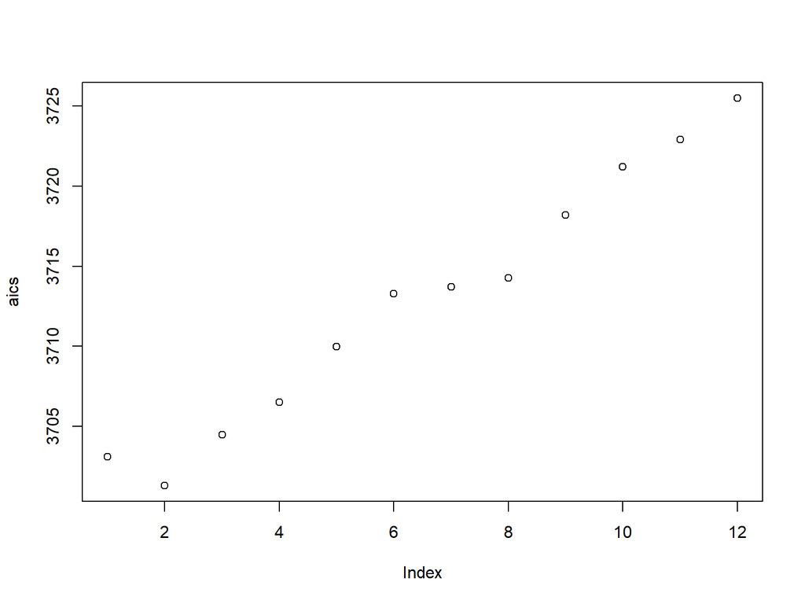

```r
aics<-c(AIC(fit_psei1),AIC(fit_psei2),AIC(fit_psei3),AIC(fit_psei4),AIC(fit_psei5),AIC(fit_psei6),AIC(fit_psei7),AIC(fit_psei8),AIC(fit_psei9),AIC(fit_psei10),AIC(fit_psei11),AIC(fit_psei12))
plot(aics)
```

This is the plot of the 1st ARIMA model.

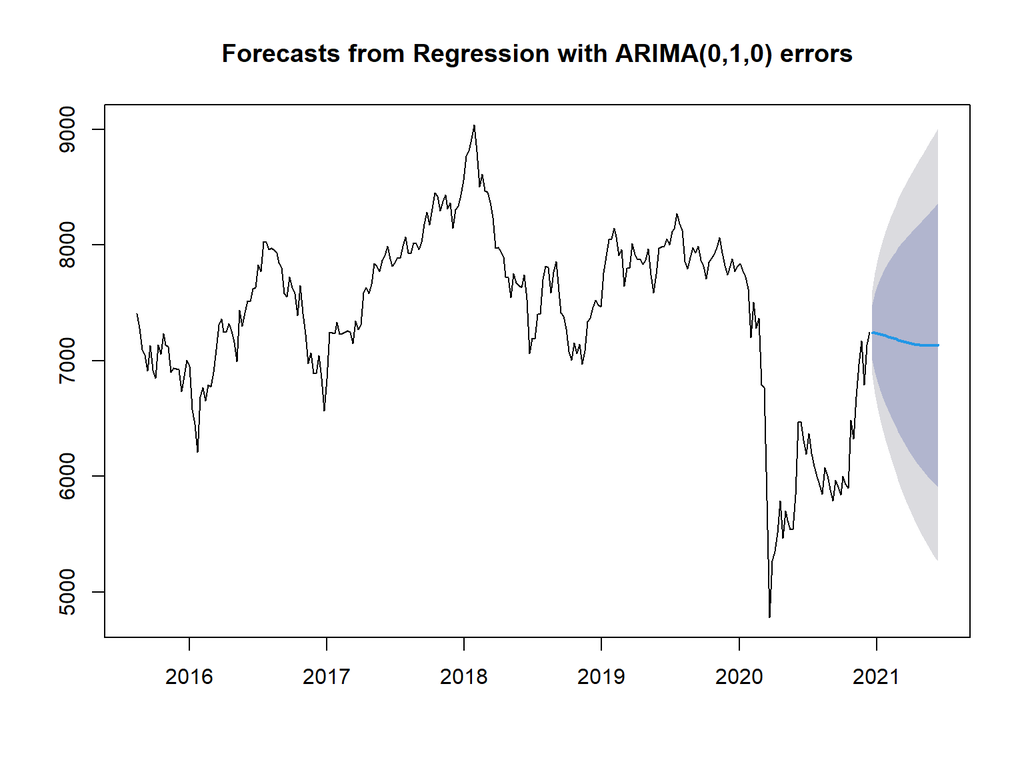

```r
fc_psei1 <- forecast(fit_psei1, xreg=fourier(psei, K=1, h=26))
plot(fc_psei1)
```

These are the point forecast, the 80% and the 95% confidence interval.

```r
fc_psei1
```

```
##          Point Forecast    Lo 80    Hi 80    Lo 95    Hi 95
## 2020.966       7242.603 7002.222 7482.985 6874.971 7610.235
## 2020.985       7238.296 6898.345 7578.247 6718.386 7758.206
## 2021.004       7233.300 6816.946 7649.653 6596.542 7870.057
## 2021.023       7227.687 6746.924 7708.451 6492.424 7962.951
## 2021.042       7221.540 6684.031 7759.050 6399.490 8043.590
## 2021.062       7214.948 6626.135 7803.760 6314.437 8115.458
## 2021.081       7208.005 6572.015 7843.995 6235.342 8180.667
## 2021.100       7200.812 6520.910 7880.714 6160.992 8240.632
## 2021.119       7193.474 6472.329 7914.618 6090.578 8296.369
## 2021.138       7186.096 6425.943 7946.249 6023.542 8348.650
## 2021.157       7178.786 6381.530 7976.042 5959.489 8398.083
## 2021.177       7171.649 6338.943 8004.356 5898.135 8445.164
## 2021.196       7164.789 6298.081 8031.498 5839.274 8490.305
## 2021.215       7158.306 6258.880 8057.731 5782.753 8533.858
## 2021.234       7152.292 6221.298 8083.286 5728.460 8576.124
## 2021.253       7146.835 6185.309 8108.362 5676.308 8617.363
## 2021.272       7142.015 6150.896 8133.134 5626.230 8657.800
## 2021.292       7137.901 6118.048 8157.753 5578.170 8697.631
## 2021.311       7134.552 6086.753 8182.351 5532.081 8737.022
## 2021.330       7132.017 6056.998 8207.036 5487.917 8776.117
## 2021.349       7130.333 6028.766 8231.900 5445.632 8815.034
## 2021.368       7129.524 6002.034 8257.014 5405.177 8853.871
## 2021.387       7129.602 5976.772 8282.432 5366.501 8892.703
## 2021.407       7130.566 5952.941 8308.190 5329.544 8931.587
## 2021.426       7132.401 5930.493 8334.309 5294.241 8970.561
## 2021.445       7135.082 5909.371 8360.792 5260.519 9009.644
```

# Accuray Measures

These are the accuracy measures for each model.

```r
accuracy(fc_psei)
```

```
##                      ME     RMSE      MAE         MPE     MAPE      MASE
## Training set -0.9257393 164.5662 123.2156 -0.04584779 1.735195 0.1510338
##                     ACF1
## Training set 0.009483672
```

```r
accuracy(fc_arima_psei)
```

```
##                     ME     RMSE      MAE         MPE     MAPE      MASE
## Training set -0.610717 184.6221 131.8597 -0.04753934 1.877225 0.1616295
##                     ACF1
## Training set -0.01308952
```

```r
accuracy(fc_psei1)
```

```
##                      ME     RMSE      MAE         MPE     MAPE      MASE
## Training set -0.7638461 186.5596 133.3621 -0.05103483 1.895593 0.1634711
##                     ACF1
## Training set 0.006575347
```